# Assingmet6

LeeJoon Jeon

## Sentiment Analysis on Twitter Dataset

### 1. 모델을 수립하기 전에 데이터의 특성을 분석한다. 시각화 도구를 적절히 활용하자.

```r
setwd('/Users/Administrator/Desktop/데분')
library(ggplot2)
library(wordcloud)
library(tm)
library(SnowballC)
library(rsample)
library(caret)
library(e1071)
library(rpart)
library(rpart.plot)
library(randomForest)
library(nnet)
```

```r
#데이터 가져오기
tw <- read.csv("Tweets.csv", stringsAsFactors = FALSE, encoding = "UTF-8")
str(tw)
```

```
## 'data.frame':    14640 obs. of  15 variables:
##  $ tweet_id                    : num  5.7e+17 5.7e+17 5.7e+17 5.7e+17 5.7e+17 ...
##  $ airline_sentiment           : chr  "neutral" "positive" "neutral" "negative" ...
##  $ airline_sentiment_confidence: num  1 0.349 0.684 1 1 ...
##  $ negativereason              : chr  "" "" "" "Bad Flight" ...
##  $ negativereason_confidence   : num  NA 0 NA 0.703 1 ...
##  $ airline                     : chr  "Virgin America" "Virgin America" "Virgin America" "Virgin America" ...
##  $ airline_sentiment_gold      : chr  "" "" "" "" ...
##  $ name                        : chr  "cairdin" "jnardino" "yvonnalynn" "jnardino" ...
##  $ negativereason_gold         : chr  "" "" "" "" ...
##  $ retweet_count               : int  0 0 0 0 0 0 0 0 0 0 ...
##  $ text                        : chr  "@VirginAmerica What @dhepburn said." "@VirginAmerica plus you've added commercials to the experience... tacky." "@VirginAmerica I didn't today... Must mean I need to take another trip!" "@VirginAmerica it's really aggressive to blast obnoxious \"entertainmen…
##  $ tweet_coord                 : chr  "" "" "" "" ...
##  $ tweet_created               : chr  "2015-02-24 11:35:52 -0800" "2015-02-24 11:15:59 -0800" "2015-02-24 11:15:48 -0800" "2015-02-24 11:15:36 -0800" ...
##  $ tweet_location              : chr  "" "" "Lets Play" "" ...
##  $ user_timezone               : chr  "Eastern Time (US & Canada)" "Pacific Time (US & Canada)" "Central Time (US & Canada)" "Pacific Time (US & Canada)" ...
```

```r
table(tw$airline_sentiment)
```

```
##
## negative  neutral positive
##     9178     3099     2363
```

```r
table(tw$airline)
```

```
##
##       American          Delta      Southwest         United     US Airways
##           2759           2222           2420           3822           2913
## Virgin America
##            504
```

```r
table(tw$negativereason)
```

```
##
##                                              Bad Flight
##                        5462                         580
##                  Can't Tell            Cancelled Flight
##                        1190                         847
##      Customer Service Issue             Damaged Luggage
##                        2910                          74
## Flight Attendant Complaints     Flight Booking Problems
##                         481                         529
##                 Late Flight                   longlines
##                        1665                         178
##                Lost Luggage
##                         724
```

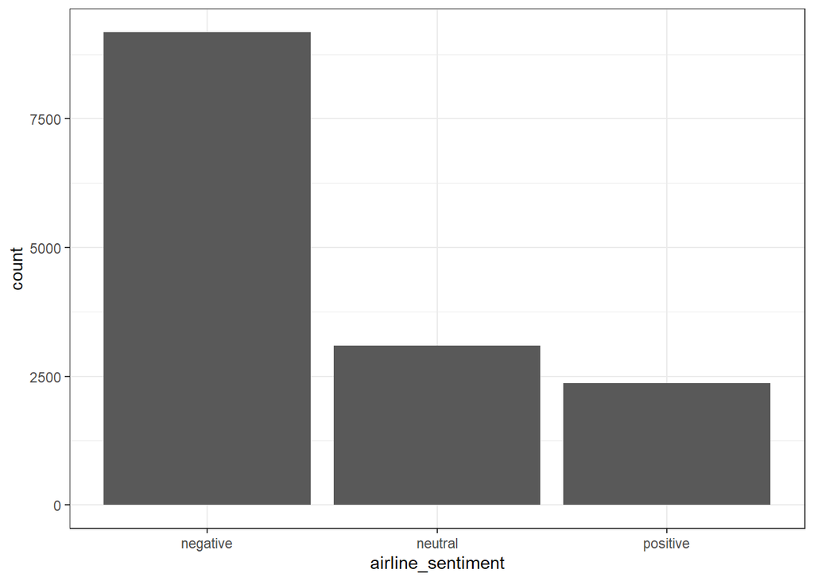

```r
#긍정,부정,중립 내용
ggplot(tw, aes(x=airline_sentiment)) + geom_bar() + theme_bw()
```

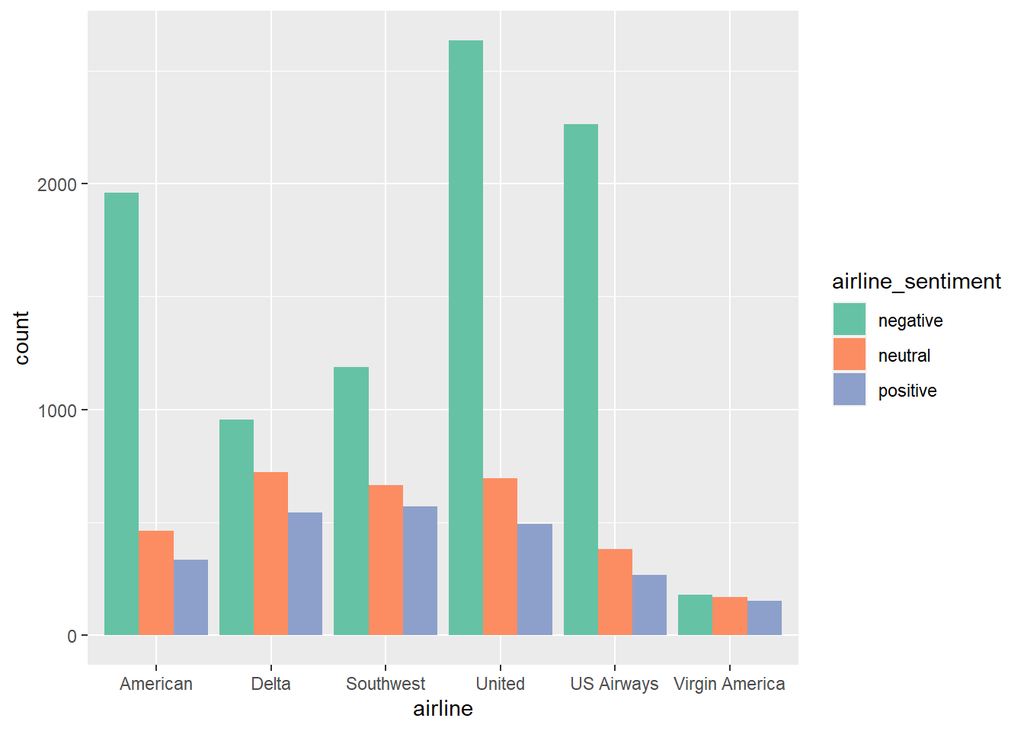

```r
#항공사별 평가
ggplot(tw,aes(x=airline,fill=airline_sentiment)) + geom_bar(position = position_dodge(preserve = "single")) + scale_fill_brewer(palette = "Set2")
```

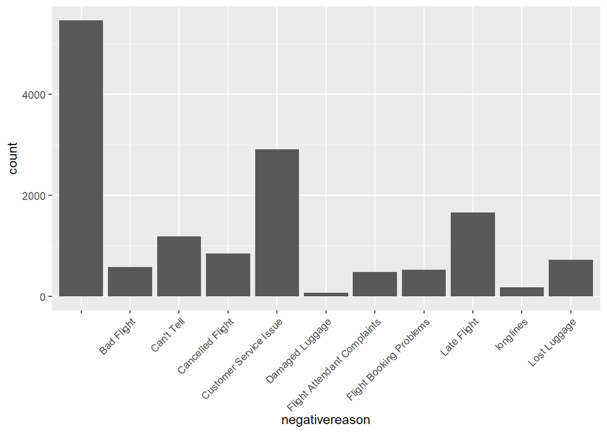

```r
#평가가 negative인 이유 수
ggplot(tw, aes(x=negativereason)) + geom_bar() + theme(axis.text.x = element_text(angle = 45,hjust = 1))
```

#### 항공사에 대해 부정적인 내용이 가장 많았고 긍정적인 내용이 가장 적었다. 항공사에 대해 평가에서 American, United, US Airways 항공사에 대한 의견은 부정적인 의견이 압도적으로 많았다. Delta, Southwest 항공사는 부정적인 의견이 많지만 중립적인 의견과 긍정적인 의견과 큰 차이가 나지 않았다. Virgin America 항공사는 세 가지 의견이 비슷하게 나타난다.

#### 부정적인 이유로는 Customer servic issue가 높은 비율로 나왔고 그 뒤로 Lagte Flight, Can’t Tell이 있다. 그리고 아무런 이유를 제시하지 않은 경우가 가장 많았다.

```r
#필요없는 features 제거
tw <- tw[,-1]
tw <- tw[,-2:-9]
tw <- tw[,-3:-6]
str(tw)
```

```
## 'data.frame':    14640 obs. of  2 variables:
##  $ airline_sentiment: chr  "neutral" "positive" "neutral" "negative" ...
##  $ text             : chr  "@VirginAmerica What @dhepburn said." "@VirginAmerica plus you've added commercials to the experience... tacky." "@VirginAmerica I didn't today... Must mean I need to take another trip!" "@VirginAmerica it's really aggressive to blast obnoxious \"entertainment\" in your…
```

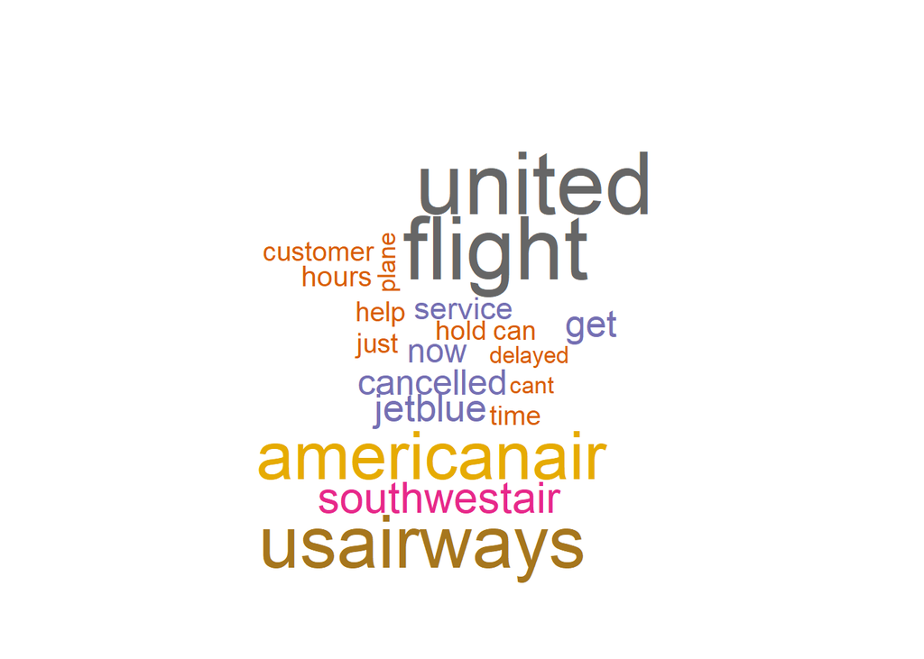

```r
#factor화
tw$airline_sentiment <- factor(tw$airline_sentiment)

# negative, positive, neutral text 분리
neg <- subset(tw, airline_sentiment == "negative")
pos <- subset(tw, airline_sentiment == "positive")
neut <- subset(tw, airline_sentiment == "neutral")

#wordcloud 생성
wordcloud(neg$text, max.words = 20, colors = brewer.pal(8, "Dark2"))
```

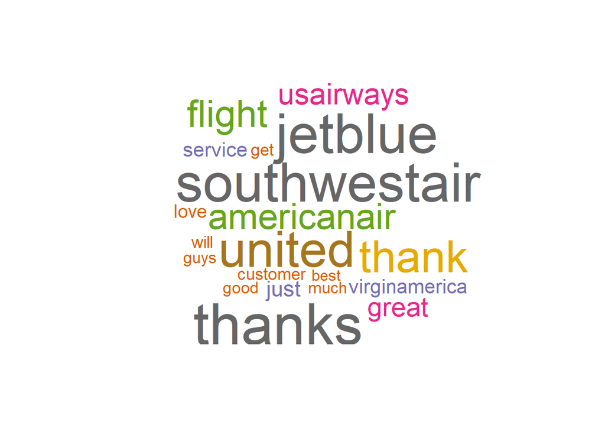

```r
wordcloud(pos$text, max.words=20, colors = brewer.pal(8, "Dark2"))
```

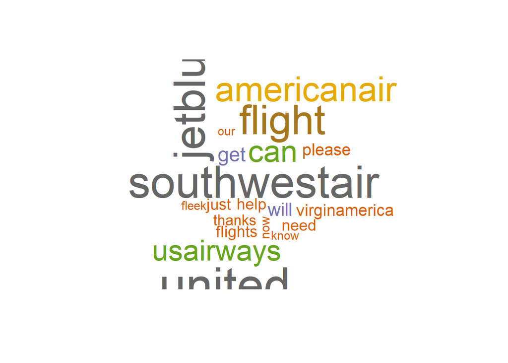

```r
wordcloud(neut$text, max.words=20, colors = brewer.pal(8, "Dark2"))
```

#### 부정적인 내용에서는 cant, delayed, cancelled등의 단어가 많이 나오는 것을 볼 수 있다.

#### 긍정적인 내용에서는 great,best,love,good 등의 단어가 많이 나온다.

#### 중립적인 내용에서는 need, pleas, canr 등의 단어가 많이 나온다.

### 2.텍스트 데이터에 bag-of-words 기법을 적용하기 위해 적절한 preprocessing을 수행하고, 그 결과를 분석해보자

```r
#corpus 생성
tw_corpus <- VCorpus(VectorSource(tw$text))
tw_corpus
```

```
## <<VCorpus>>
## Metadata:  corpus specific: 0, document level (indexed): 0
## Content:  documents: 14640
```

```r
#300번째 document 확인
inspect(tw_corpus[[300]])
```

```
## <<PlainTextDocument>>
## Metadata:  7
## Content:  chars: 67
##
## @VirginAmerica weather delays &gt; next few weeks ;) #JFK #BOS #DCA
```

```r
tw_corpus[[300]]$content
```

```
## [1] "@VirginAmerica weather delays &gt; next few weeks ;) #JFK #BOS #DCA"
```

```r
#대문자를 소문자로 변환
tw_corpus_clean <- tm_map(tw_corpus, content_transformer(tolower))
tw_corpus_clean[[300]]$content
```

```
## [1] "@virginamerica weather delays &gt; next few weeks ;) #jfk #bos #dca"
```

```r
#숫자 제거
tw_corpus_clean <- tm_map(tw_corpus_clean, removeNumbers)

#stopword 츨력
stopwords()
```

```
##   [1] "i"          "me"         "my"         "myself"     "we"
##   [6] "our"        "ours"       "ourselves"  "you"        "your"
##  [11] "yours"      "yourself"   "yourselves" "he"         "him"
##  [16] "his"        "himself"    "she"        "her"        "hers"
##  [21] "herself"    "it"         "its"        "itself"     "they"
##  [26] "them"       "their"      "theirs"     "themselves" "what"
##  [31] "which"      "who"        "whom"       "this"       "that"
##  [36] "these"      "those"      "am"         "is"         "are"
##  [41] "was"        "were"       "be"         "been"       "being"
##  [46] "have"       "has"        "had"        "having"     "do"
##  [51] "does"       "did"        "doing"      "would"      "should"
##  [56] "could"      "ought"      "i'm"        "you're"     "he's"
##  [61] "she's"      "it's"       "we're"      "they're"    "i've"
##  [66] "you've"     "we've"      "they've"    "i'd"        "you'd"
##  [71] "he'd"       "she'd"      "we'd"       "they'd"     "i'll"
```

[output cut: 20 more lines]

```r
#stopword 제거
tw_corpus_clean <- tm_map(tw_corpus_clean, removeWords, stopwords())
tw_corpus_clean[[300]]$content
```

```
## [1] "@virginamerica weather delays &gt; next  weeks ;) #jfk #bos #dca"
```

```r
#문장부호 제거
tw_corpus_clean <- tm_map(tw_corpus_clean, removePunctuation)
tw_corpus_clean[[300]]$content
```

```
## [1] "virginamerica weather delays gt next  weeks  jfk bos dca"
```

```r
#stemming
tw_corpus_clean <- tm_map(tw_corpus_clean, stemDocument)
tw_corpus_clean[[300]]$content
```

```
## [1] "virginamerica weather delay gt next week jfk bos dca"
```

```r
#공백제거
tw_corpus_clean <- tm_map(tw_corpus_clean, stripWhitespace)
tw_corpus_clean[[300]]$content
```

```
## [1] "virginamerica weather delay gt next week jfk bos dca"
```

```r
#document-term matrix
tw_dtm <- DocumentTermMatrix(tw_corpus_clean)
tw_dtm
```

```
## <<DocumentTermMatrix (documents: 14640, terms: 11274)>>
## Non-/sparse entries: 136252/164915108
## Sparsity           : 100%
## Maximal term length: 46
## Weighting          : term frequency (tf)
```

```r
inspect(tw_dtm)
```

```
## <<DocumentTermMatrix (documents: 14640, terms: 11274)>>
## Non-/sparse entries: 136252/164915108
## Sparsity           : 100%
## Maximal term length: 46
## Weighting          : term frequency (tf)
## Sample             :
##       Terms
## Docs   americanair can flight get hour jetblu southwestair thank unit usairway
##   1076           0   0      5   0    0      0            0     0    1        0
##   2363           0   0      0   0    0      0            0     0    1        0
##   2945           0   0      0   1    0      0            0     0    2        0
##   3698           0   0      2   0    0      0            0     0    1        0
##   376            0   0      2   0    0      0            0     0    0        0
##   3871           0   0      0   1    0      0            0     1    1        0
##   3995           0   0      0   0    0      0            0     0    1        0
##   4797           0   0      2   0    1      0            1     0    0        0
##   827            0   0      1   0    0      0            0     0    1        0
##   974            0   0      2   0    0      0            0     0    1        0
```

```r
#TF-IDF
tw_tfidf <- weightTfIdf(tw_dtm)
inspect(tw_tfidf[1:5,])
```

```
## <<DocumentTermMatrix (documents: 5, terms: 11274)>>
## Non-/sparse entries: 32/56338
## Sparsity           : 100%
## Maximal term length: 46
## Weighting          : term frequency - inverse document frequency (normalized) (tf-idf)
## Sample             :
##     Terms
## Docs      bad      big commerci dhepburn     plus    realli     said    tacki
##    1 0.000000 0.000000 0.000000 4.612543 0.000000 0.0000000 2.131561 0.000000
##    2 0.000000 0.000000 1.950033 0.000000 1.590997 0.0000000 0.000000 2.767526
##    3 0.000000 0.000000 0.000000 0.000000 0.000000 0.0000000 0.000000 0.000000
##    4 0.000000 0.000000 0.000000 0.000000 0.000000 0.5116522 0.000000 0.000000
##    5 1.261249 1.537576 0.000000 0.000000 0.000000 1.1256349 0.000000 0.000000
##     Terms
## Docs    thing virginamerica
##    1 0.000000     1.6134828
##    2 0.000000     0.9680897
##    3 0.000000     0.6050561
##    4 0.000000     0.4400408
##    5 1.367526     0.9680897
```

```r
#전체 document에서 0.5%미만의 document에서 발생하는 단어 제외
tw_dtm2 <- removeSparseTerms(tw_dtm, 0.995)
tw_dtm2
```

```
## <<DocumentTermMatrix (documents: 14640, terms: 330)>>
## Non-/sparse entries: 90845/4740355
## Sparsity           : 98%
## Maximal term length: 17
## Weighting          : term frequency (tf)
```

```r
#documnet-trem matrix를 데이터 프레임으로 변환
tw_frame <- data.frame(as.matrix(tw_dtm2))

#feature의 이름을 적당한 형태로 조정
colnames(tw_frame) <- make.names(colnames(tw_frame))

#target variable 추가
tw_frame$airline_sentiment <- tw$airline_sentiment
```

#### 전체 document에서 0.5%미만의 document에서 발생하는 단어 제외했더니 단어 수가 11274개에서 330개로 감소했다.

### 3. 계산시간을 줄이기 위해서 첫 5,000개의 데이터만 training set으로 사용하고, 나머지 모든 데이터를 test set으로 사용한다. Training set을 사용하여 predictive model을 만들어보자.

#### A. 지금까지 학습한 모델을 최대한 활용해보고, 분석 과정과 결과를 report하자. 사용하는 모델, 모델에 포함되는 파라미터에 대한 튜닝, 모델에 포함되는 feature의 수, DTM/TF-IDF 사용 여부 등이 classification accuracy에 영향을 미칠 수 있다.

[주의: 모델을 수립할 때에는 test set을 사용하여 성능을 비교할 수 없다.]

```r
#train, test set 분할
train <- tw_frame[1:5000,]
test <- tw_frame[-1:-5000,]


set.seed(123)
#train, validaion set 분할
split <- initial_split(train, prop = 0.8, strata = "airline_sentiment")
train <- training(split)
validation <- testing(split)

#svm model
set.seed(12)
svm_m <- tune(svm, airline_sentiment ~., data=train, kernel = "radial", ranges=list(cost=c(0.01,0.1,1,10,100,1000), gamma = c(0.01,0.1,1,10,100)))
summary(svm_m)
```

```
##
## Parameter tuning of 'svm':
##
## - sampling method: 10-fold cross validation
##
## - best parameters:
##  cost gamma
##    10  0.01
##
## - best performance: 0.2718653
##
## - Detailed performance results:
##     cost gamma     error dispersion
## 1  1e-02 1e-02 0.3740617 0.01522700
## 2  1e-01 1e-02 0.3740617 0.01522700
```

[output cut: 28 more lines]

```r
#validation set에 대한 예측 및 confusionmatrix
pred <- predict(svm_m$best.model, newdata = validation)
confusionMatrix(pred, validation$airline_sentiment)
```

```
## Confusion Matrix and Statistics
##
##           Reference
## Prediction negative neutral positive
##   negative      581     107       49
##   neutral        28      81       25
##   positive       16      23       88
##
## Overall Statistics
##
##                Accuracy : 0.7515
##                  95% CI : (0.7235, 0.778)
##     No Information Rate : 0.6263
##     P-Value [Acc > NIR] : < 2e-16
##
##                   Kappa : 0.4913
##
##  Mcnemar's Test P-Value : 1.3e-13
##
## Statistics by Class:
##
##                      Class: negative Class: neutral Class: positive
## Sensitivity                   0.9296        0.38389         0.54321
## Specificity                   0.5818        0.93266         0.95335
## Pos Pred Value                0.7883        0.60448         0.69291
## Neg Pred Value                0.8314        0.84954         0.91504
## Prevalence                    0.6263        0.21142         0.16232
## Detection Rate                0.5822        0.08116         0.08818
## Detection Prevalence          0.7385        0.13427         0.12725
## Balanced Accuracy             0.7557        0.65827         0.74828
```

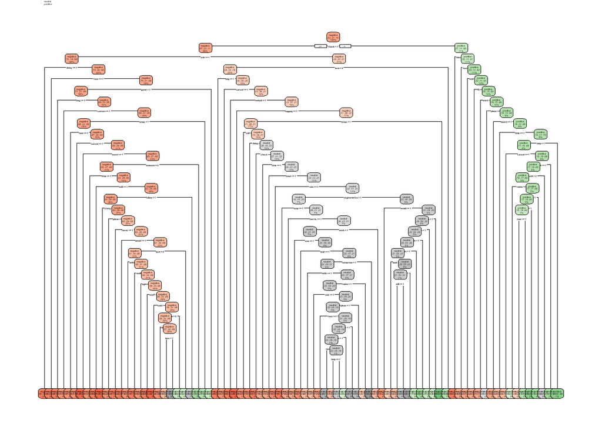

```r
#classification tree
set.seed(13)
ct_m <- rpart(airline_sentiment ~., data=train, method="class", control=list(cp=0))
rpart.plot(ct_m)
```

```r
printcp(ct_m)
```

```
##
## Classification tree:
## rpart(formula = airline_sentiment ~ ., data = train, method = "class",
##     control = list(cp = 0))
##
## Variables actually used in tree construction:
##  [1] agent         airlin        amaz          amp           awesom
##  [6] back          bag           board         call          can
## [11] cancel        charg         check         custom        delay
## [16] email         even          fli           follow        great
## [21] help          hour          just          leav          look
## [26] love          luggag        made          make          min
## [31] miss          need          never         now           one
## [36] peopl         plane         pleas         realli        said
## [41] seat          see           servic        site          staff
```

[output cut: 25 more lines]

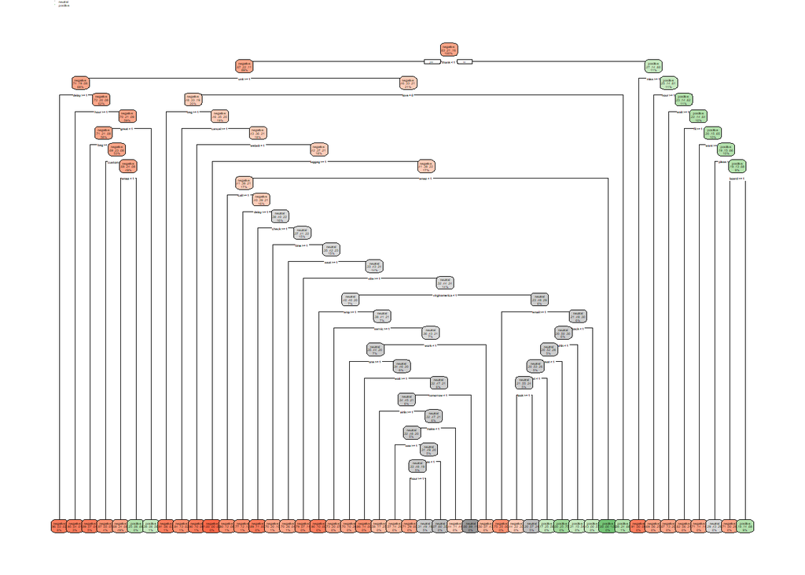

```r
#cv error가 가장 낮을 때의 cp값
best_cp <- ct_m$cptable[which.min(ct_m$cptable[,"xerror"]),"CP"]

#best cp 일 때 pruned tree생성
best_ct <- prune(ct_m, cp=best_cp)
rpart.plot(best_ct)
```

```r
#validation set에 대한 예측 및 confusionmatrix
pred_prob <- predict(best_ct, newdata = validation, type = "prob")
pred_class <- predict(best_ct, newdata=validation, type = "class")
confusionMatrix(factor(pred_class),validation$airline_sentiment)
```

```
## Confusion Matrix and Statistics
##
##           Reference
## Prediction negative neutral positive
##   negative      571     136       62
##   neutral        31      55       26
##   positive       23      20       74
##
## Overall Statistics
##
##                Accuracy : 0.7014
##                  95% CI : (0.6719, 0.7297)
##     No Information Rate : 0.6263
##     P-Value [Acc > NIR] : 3.718e-07
##
##                   Kappa : 0.371
##
##  Mcnemar's Test P-Value : < 2.2e-16
##
## Statistics by Class:
##
##                      Class: negative Class: neutral Class: positive
## Sensitivity                   0.9136        0.26066         0.45679
## Specificity                   0.4692        0.92757         0.94856
## Pos Pred Value                0.7425        0.49107         0.63248
## Neg Pred Value                0.7642        0.82393         0.90011
## Prevalence                    0.6263        0.21142         0.16232
## Detection Rate                0.5721        0.05511         0.07415
## Detection Prevalence          0.7705        0.11222         0.11723
## Balanced Accuracy             0.6914        0.59412         0.70268
```

```r
#bagging model
set.seed(14)
bag <- randomForest(airline_sentiment ~ ., data = train, mtry = ncol(train)-1)
bag
```

```
##
## Call:
##  randomForest(formula = airline_sentiment ~ ., data = train, mtry = ncol(train) -      1)
##                Type of random forest: classification
##                      Number of trees: 500
## No. of variables tried at each split: 330
##
##         OOB estimate of  error rate: 30.68%
## Confusion matrix:
##          negative neutral positive class.error
## negative     2088     272      145   0.1664671
## neutral       401     339      106   0.5992908
## positive      195     109      347   0.4669739
```

```r
#train set 에 대한 confusion
bag$confusion
```

```
##          negative neutral positive class.error
## negative     2088     272      145   0.1664671
## neutral       401     339      106   0.5992908
## positive      195     109      347   0.4669739
```

```r
#bagging model의 validation set에 대한 예측
pred_bag <- predict(bag, newdata = validation, type = "class")
confusionMatrix(pred_bag,validation$airline_sentiment)
```

```
## Confusion Matrix and Statistics
##
##           Reference
## Prediction negative neutral positive
##   negative      525      99       52
##   neutral        73      89       17
##   positive       27      23       93
##
## Overall Statistics
##
##                Accuracy : 0.7084
##                  95% CI : (0.6791, 0.7365)
##     No Information Rate : 0.6263
##     P-Value [Acc > NIR] : 2.904e-08
##
##                   Kappa : 0.4334
##
##  Mcnemar's Test P-Value : 0.00523
##
## Statistics by Class:
##
##                      Class: negative Class: neutral Class: positive
## Sensitivity                   0.8400        0.42180         0.57407
## Specificity                   0.5952        0.88564         0.94019
## Pos Pred Value                0.7766        0.49721         0.65035
## Neg Pred Value                0.6894        0.85104         0.91930
## Prevalence                    0.6263        0.21142         0.16232
## Detection Rate                0.5261        0.08918         0.09319
## Detection Prevalence          0.6774        0.17936         0.14329
## Balanced Accuracy             0.7176        0.65372         0.75713
```

```r
#random foerest model
set.seed(15)
rf_m <- randomForest(airline_sentiment~., data = train)

#train set에 대한 confusion matrix
rf_m$confusion
```

```
##          negative neutral positive class.error
## negative     2192     215       98   0.1249501
## neutral       443     316       87   0.6264775
## positive      203      97      351   0.4608295
```

```r
#random forest model에서 validation set에 대한 예측
pred_rf <- predict(rf_m, newdata = validation, type = "class")
confusionMatrix(pred_rf, validation$airline_sentiment)
```

```
## Confusion Matrix and Statistics
##
##           Reference
## Prediction negative neutral positive
##   negative      558     101       52
##   neutral        48      86       23
##   positive       19      24       87
##
## Overall Statistics
##
##                Accuracy : 0.7325
##                  95% CI : (0.7038, 0.7597)
##     No Information Rate : 0.6263
##     P-Value [Acc > NIR] : 7.809e-13
##
##                   Kappa : 0.4643
##
##  Mcnemar's Test P-Value : 1.787e-07
##
## Statistics by Class:
##
##                      Class: negative Class: neutral Class: positive
## Sensitivity                   0.8928        0.40758         0.53704
## Specificity                   0.5898        0.90978         0.94856
## Pos Pred Value                0.7848        0.54777         0.66923
## Neg Pred Value                0.7666        0.85137         0.91359
## Prevalence                    0.6263        0.21142         0.16232
## Detection Rate                0.5591        0.08617         0.08717
## Detection Prevalence          0.7124        0.15731         0.13026
## Balanced Accuracy             0.7413        0.65868         0.74280
```

```r
#multinorm logistic model
mlogit_m <- multinom(airline_sentiment ~., data=train)
summary(mlogit_m)
```

```
## Call:
## multinom(formula = airline_sentiment ~ ., data = train)
##
## Coefficients:
##          (Intercept) X.jetblu        abl     account     actual       add
## neutral    0.7139673        0 -0.5481404  -0.0664322 -0.2314226  1.236646
## positive  -1.4660299        0  0.7838757 -11.4717765 -2.5374670 -0.170264
##               agent        ago       air      airlin    airport     airway
## neutral  -1.8163668  0.6586837 0.8626477 -0.87782294 -0.4754478 11.9918317
## positive  0.1552808 -0.8447539 0.0993304  0.06379002  0.2869022 -0.8726753
##              allow     almost    alreadi        also      alway      amaz
## neutral   1.175124 -1.0351631 -0.5540167 -0.05498502 -1.7219285 0.5623501
## positive -9.472209 -0.4448518 -0.7608787 -1.82823659  0.8028495 4.0012119
##           american americanair        amp      anoth     answer     anyon
## neutral  -9.720423  -0.3703182 -0.3678074 -0.2337670 -15.115334 -1.918608
## positive -7.348462  -0.9446742 -0.3192965 -0.4470704  -2.636423 -9.423569
##              anyth     apolog        app   appreci      arriv         ask
## neutral  -1.427389 -1.1656156 -0.0642681 0.8060842  0.3853737 -0.02444917
## positive -1.777206 -0.6214242 -0.7667162 2.2007004 -0.2121602 -0.42339496
##              assist    attend       avail       away     awesom        back
## neutral  -0.6607261 -1.541336 0.003726956 -2.4791518 -0.4195621  0.09283047
## positive -0.7607394  1.418897 0.083468632 -0.5471085  2.9315368 -0.21777357
##                bad       bag    baggag      best     better      board
## neutral  -1.554829 -1.284750 0.3124256 0.4181265 -3.0777130 -0.3946864
## positive -1.210818 -1.029793 0.4254179 1.9388470  0.1134303 -0.3152588
##                  book    boston       busi      call        can    cancel
## neutral  -0.006679292 -1.213326 -0.9113782 -1.427139  0.8984568 -2.350259
## positive -0.253327411 -1.191268 -1.4504208 -1.129837 -0.4226246 -1.608047
##                 card        care        caus      chanc      chang      charg
## neutral  -0.05263273 -1.00907872  -0.5119437  0.5425692 -0.2580510 -14.408698
## positive -1.48491235  0.03466866 -12.2514318 -1.7840616 -0.3175778  -2.005173
##                check   chicago     claim     class       clt        come
## neutral  -0.05084807 1.1337391 -1.516226 0.8252181  3.311279  0.02636364
## positive -0.17349229 0.3378663 -1.806424 1.7152427 -6.793889 -1.27575258
##             compani      confirm    connect     contact        cost    credit
## neutral  -0.9459246  0.001973145 -0.2221052 -0.11613408   0.4171836 0.4229356
## positive -0.2516582 -1.167444946  0.2766848  0.04527063 -11.0485172 0.1248873
##                crew     custom      dalla        day        dca      deal
## neutral  -1.2763641 -1.2266715 -0.8366753 -0.5767598 1.82447451 0.8950560
## positive  0.4734311 -0.3241847 -1.4656586  0.1399804 0.04581787 0.9187416
```

[output cut: 275 more lines]

```
##               vega       via virginamerica   voucher      wait      want
## neutral  0.5630023 0.6257483     0.2897649 0.5504688 0.4160222 0.3782477
## positive 0.9276636 0.7687875     0.3689657 0.7965212 0.4472514 0.6321666
##                way   weather   websit      week      well     wife      wifi
## neutral  0.3232544 0.4173858 0.674096 0.4892847 0.6334610 1.276331 0.6665057
## positive 0.3925308 0.7220587 1.102753 0.5771615 0.5325465 1.266965 0.6217065
##               will   without      work        worst       wrong      year
## neutral  0.2311918 0.6746835 0.4827405 4.834761e-05   0.7630508 0.4613731
## positive 0.3096691 1.1872895 0.4198430 1.845407e-04 132.6799009 0.5463152
##                yes yesterday       yet
## neutral  0.3900076 0.6973071 0.5218166
## positive 0.4826810 1.1052546 1.3716622
##
## Residual Deviance: 3937.672
## AIC: 5253.672
```

```r
#validation set에 대한 예측 및 confusionmatrix
pred_ml <- predict(mlogit_m, newdata = validation, type = "class")
confusionMatrix(pred_ml, validation$airline_sentiment)
```

```
## Confusion Matrix and Statistics
##
##           Reference
## Prediction negative neutral positive
##   negative      533      81       38
##   neutral        69     111       30
##   positive       23      19       94
##
## Overall Statistics
##
##                Accuracy : 0.7395
##                  95% CI : (0.7111, 0.7665)
##     No Information Rate : 0.6263
##     P-Value [Acc > NIR] : 2.119e-14
##
##                   Kappa : 0.5031
##
##  Mcnemar's Test P-Value : 0.06823
##
## Statistics by Class:
##
##                      Class: negative Class: neutral Class: positive
## Sensitivity                   0.8528         0.5261         0.58025
## Specificity                   0.6810         0.8742         0.94976
## Pos Pred Value                0.8175         0.5286         0.69118
## Neg Pred Value                0.7341         0.8731         0.92111
## Prevalence                    0.6263         0.2114         0.16232
## Detection Rate                0.5341         0.1112         0.09419
## Detection Prevalence          0.6533         0.2104         0.13627
## Balanced Accuracy             0.7669         0.7001         0.76500
```

#### Accuracy를 비교해 보면 사용한 model들의 Accuracy가 70%가 넘는 것을 볼 수 있다. 이중 SVM model이 가장 높은 Accuracy를 보여준다.

| model | svm | tree | bagging | random forest | 다항로지스틱 |
| --- | --- | --- | --- | --- | --- |
| Accuracy | 0.7515 | 0.7014 | 0.7084 | 0.7325 | 0.7395 |

#### 각 model에서 각 class(negive, neutral, positive)별로 분류가 정확한지 따져보면 모든 model에서 negative, positive, neutral 순으로 분류가 정확한다것을 알 수 있다.

| model | svm | tree | bagging | random forest | 다항로지스틱 |
| --- | --- | --- | --- | --- | --- |
| Sensitivity | 0.9296 | 0.9136 | 0.8400 | 0.8928 | 0.8528 |
| (negative) |  |  |  |  |  |

| model | svm | tree | bagging | random forest | 다항로지스틱 |
| --- | --- | --- | --- | --- | --- |
| Sensitivity | 0.38389 | 0.26066 | 0.42180 | 0.40758 | 0.5261 |
| (neutral) |  |  |  |  |  |

| model | svm | tree | bagging | random forest | 다항로지스틱 |
| --- | --- | --- | --- | --- | --- |
| Sensitivity | 0.54321 | 0.45679 | 0.57407 | 0.53704 | 0.58025 |
| (positive) |  |  |  |  |  |

### B.최종적으로 선택한 모델은 무엇이며 test set에 대한 accuracy는 얼마인가?

```r
#svm model선택
#test set에 대한 예측
pred_svm <- predict(svm_m$best.model, newdata = test)
confusionMatrix(pred_svm, test$airline_sentiment)
```

```
## Confusion Matrix and Statistics
##
##           Reference
## Prediction negative neutral positive
##   negative     5209     937      453
##   neutral       655     943      193
##   positive      184     162      904
##
## Overall Statistics
##
##                Accuracy : 0.732
##                  95% CI : (0.723, 0.7408)
##     No Information Rate : 0.6274
##     P-Value [Acc > NIR] : < 2.2e-16
##
##                   Kappa : 0.4747
##
##  Mcnemar's Test P-Value : < 2.2e-16
##
## Statistics by Class:
##
##                      Class: negative Class: neutral Class: positive
## Sensitivity                   0.8613        0.46180         0.58323
## Specificity                   0.6130        0.88839         0.95723
## Pos Pred Value                0.7894        0.52652         0.72320
## Neg Pred Value                0.7241        0.85998         0.92300
## Prevalence                    0.6274        0.21183         0.16079
## Detection Rate                0.5404        0.09782         0.09378
## Detection Prevalence          0.6845        0.18579         0.12967
## Balanced Accuracy             0.7372        0.67510         0.77023
```

#### Accuracy가 가장 높은 SVM model을 최종적으로 선택했고 test set에 대한 Acㅊuracy는 0.732가 나왔다. 기대한 Accuracy보다 낮은 70%대로 나왔는데 이는 계산시간을 고려하여 임의로 training set을 줄였기 때문으로 예상된다. 만약에 training set에 더 많은 data를 사용했다면 지금 나온 Accuracy보다 더 높은 결과를 얻을 수 있었을 것으로 생각되며 임의로 줄인 data를 가지고 0.732라는 Accuracy가 나온 것은 충분히 높은 Accuracy라고 생각된다.

### C. 세 class (positive, negative, neutral) 중에서 어떤 class를 분류하기 어려운가?

| Sensitivity | negative | neutral | positive |
| --- | --- | --- | --- |
| SVM | 0.8613 | 0.46180 | 0.58323 |